# Machine Learning I: Group Assignment 2: Supervised

GMBD: 2020 Intake: Group E

11/JUL/2020

# Reading data

The source data is read from the original *Excel* file.

```r
data <- read_excel(path = file.path('data', 'Houses for rent in madrid_assignment 2020.xlsx'), sheet = 'Houses_for_rent_madrid_assignme')
# skim(data)
```

# Data preparation

Some data preparation was done to the RAW data.  
Including:  
* Normalization at the address  
* Extraction of property type from the description  
* Completion of data  
* For the **Chalet**: Floor, Outer and Elevator were revised  
* For **Estudio**: Bedrooms were revised  
* For **Chalet pareado**: Floor and Outer were revised  
* For **Chalet adosado**: Floor and Outer were revised  
A summary of the data is presented.

```r
data1 <- data %>%
  mutate(
    Type = factor(ifelse(grepl('^Piso\\sen', Address), 'Piso',
                  ifelse(grepl('^Ático\\sen', Address), 'Ático',
                  ifelse(grepl('^Dúplex\\sen', Address), 'Dúplex',
                  ifelse(grepl('^Estudio\\sen', Address), 'Estudio',
                  ifelse(grepl('^Chalet\\spareado\\sen', Address), 'Chalet pareado',
                  ifelse(grepl('^Chalet\\sadosado\\sen', Address), 'Chalet adosado',
                  ifelse(grepl('^Caserón\\sen', Address), 'Chalet',
                  ifelse(grepl('^Casa\\so\\schalet\\sindependiente\\sen', Address), 'Chalet',
                  ifelse(grepl('^Chalet\\sen', Address), 'Chalet', 'Other')))))))))),
    # Fix Area
    Area = gsub('\\s-\\s', '-', Area),
    Area = gsub('^en\\s', '', Area),
    Area = gsub('chalet independiente en Nueva España', 'Nueva España', Area),
    # Chalet
    Floor = ifelse(is.na(Floor) & Type == 'Chalet', 0, Floor),
    Outer = ifelse(is.na(Outer) & Type == 'Chalet', 0, Outer),
    Elevator = ifelse(is.na(Elevator) & Type == 'Chalet', 0, Elevator),
    # Estudio
    Bedrooms = ifelse(is.na(Bedrooms) & Type == 'Estudio', 0, Bedrooms),
    # Chalet pareado
    Floor = ifelse(is.na(Floor) & Type == 'Chalet pareado', 0, Floor),
    Outer = ifelse(is.na(Outer) & Type == 'Chalet pareado', 0, Outer),
    # Chalet adosado
    Floor = ifelse(Type == 'Chalet adosado', 0, Floor), # Data error
    Outer = ifelse(is.na(Outer) & Type == 'Chalet adosado', 0, Outer),
    # Factoring
    Outer = factor(Outer, levels = c(0, 1), labels = c('No', 'Yes')),
    Elevator = factor(Elevator, levels = c(0, 1), labels = c('No', 'Yes')),
    # Type, but will be removed
    Penthouse = factor(Penthouse, levels = c(0, 1), labels = c('No', 'Yes')), # Ático
    Cottage = factor(Cottage, levels = c(0, 1), labels = c('No', 'Yes')), # Casa o chalet independiente, Caserón, Chalet, Chalet adosado, Chalet pareado
    Duplex = factor(Duplex, levels = c(0, 1), labels = c('No', 'Yes')), # Dúplex
    Semidetached = factor(Semidetached, levels = c(0, 1), labels = c('No', 'Yes')), #Chalet, Chalet adosado
    # Names
    AddressComplete = gsub(".*\\sen\\s","", Address),
    AddressComplete = paste(AddressComplete, ifelse(is.na(Number), 1, Number), Area, 'Madrid', 'Spain', sep = ', '),
    AreaComplete = paste(Area, 'Madrid', 'Spain', sep = ', '),
    AddressComplete = str_to_title(AddressComplete),
    AreaComplete =str_to_title(AreaComplete)
  )

skim(data1)
```

Data summary

| Name | data1 |
| --- | --- |
| Number of rows | 2188 |
| Number of columns | 18 |
| _______________________ |  |
| Column type frequency: |  |
| character | 6 |
| factor | 7 |
| numeric | 5 |
| ________________________ |  |
| Group variables | None |

**Variable type: character**

| skim_variable | n_missing | complete_rate | min | max | empty | n_unique | whitespace |
| --- | --- | --- | --- | --- | --- | --- | --- |
| District | 0 | 1.00 | 5 | 17 | 0 | 20 | 0 |
| Address | 0 | 1.00 | 11 | 60 | 0 | 1375 | 0 |
| Number | 1417 | 0.35 | 1 | 9 | 0 | 138 | 0 |
| Area | 4 | 1.00 | 3 | 29 | 0 | 132 | 0 |
| AddressComplete | 0 | 1.00 | 26 | 85 | 0 | 1435 | 0 |
| AreaComplete | 0 | 1.00 | 17 | 44 | 0 | 133 | 0 |

**Variable type: factor**

| skim_variable | n_missing | complete_rate | ordered | n_unique | top_counts |
| --- | --- | --- | --- | --- | --- |
| Outer | 86 | 0.96 | FALSE | 2 | Yes: 1741, No: 361 |
| Elevator | 102 | 0.95 | FALSE | 2 | Yes: 1796, No: 290 |
| Penthouse | 0 | 1.00 | FALSE | 2 | No: 2018, Yes: 170 |
| Cottage | 0 | 1.00 | FALSE | 2 | No: 2089, Yes: 99 |
| Duplex | 0 | 1.00 | FALSE | 2 | No: 2123, Yes: 65 |
| Semidetached | 0 | 1.00 | FALSE | 2 | No: 2155, Yes: 33 |
| Type | 0 | 1.00 | FALSE | 7 | Pis: 1752, Áti: 170, Est: 101, Dúp: 65 |

**Variable type: numeric**

| skim_variable | n_missing | complete_rate | mean | sd | p0 | p25 | p50 | p75 | p100 | hist |
| --- | --- | --- | --- | --- | --- | --- | --- | --- | --- | --- |
| Id | 0 | 1.00 | 1094.50 | 631.77 | 1 | 547.75 | 1094.5 | 1641.25 | 2188 | ▇▇▇▇▇ |
| Rent | 0 | 1.00 | 1946.44 | 1526.95 | 450 | 950.00 | 1400.0 | 2500.00 | 16000 | ▇▁▁▁▁ |
| Bedrooms | 7 | 1.00 | 2.39 | 1.38 | 0 | 1.00 | 2.0 | 3.00 | 8 | ▅▇▂▁▁ |
| Sq.Mt | 0 | 1.00 | 130.12 | 118.88 | 15 | 65.00 | 90.0 | 150.00 | 1300 | ▇▁▁▁▁ |
| Floor | 63 | 0.97 | 3.40 | 3.01 | -1 | 1.00 | 3.0 | 5.00 | 29 | ▇▂▁▁▁ |

# Feature engineering

## Adding geolocalization

Using the project http://nominatim.openstreetmap.org, we had converted the properties addresses to latitude and longitude.  
This allows a better representation of the properties in a map, and also better for the **regression model**.

```r
# https://datascienceplus.com/osm-nominatim-with-r-getting-locations-geo-coordinates-by-its-address/
## geocoding function using OSM Nominatim API
## details: http://wiki.openstreetmap.org/wiki/Nominatim
## made by: D.Kisler

# Function to geolocate
nominatim_osm <- function(address = NULL)
{
  if(suppressWarnings(is.null(address)))
    return(data.frame())
  tryCatch(
    d <- jsonlite::fromJSON(
      gsub('\\@addr\\@', gsub('\\s+', '\\%20', address),
           'http://nominatim.openstreetmap.org/search/@addr@?format=json&addressdetails=0&limit=1')
    ), error = function(c) return(data.frame())
  )
  if(length(d) == 0) return(data.frame())
  return(data.frame(address = address, lon = as.numeric(d$lon), lat = as.numeric(d$lat)))
}

# Group full address
data_3_temp <- data1 %>%
  group_by(AddressComplete) %>%
  summarize(n=n(), .groups = 'drop')

# Look for the geolocalization
# system.time({
#   data_geopos_address <- lapply(data_3_temp$AddressComplete, nominatim_osm) %>%
#     bind_rows()
# })
# saveRDS(object = data_geopos_address, file = file.path('storage', 'data_geopos_address.RData'))
data_geopos_address <- readRDS(file = file.path('storage', 'data_geopos_address.RData'))

# Group area
data_3_temp <- data1 %>%
  filter(!AddressComplete %in% data_geopos_address$address) %>%
  group_by(AreaComplete) %>%
  summarize(n=n(), .groups = 'drop')

# Look for the geolocalization
# system.time({
#   data_geopos_area <- lapply(data_3_temp$AreaComplete, nominatim_osm) %>%
#     bind_rows()
# })
# saveRDS(object = data_geopos_area, file = file.path('storage', 'data_geopos_area.RData'))
data_geopos_area <- readRDS(file = file.path('storage', 'data_geopos_area.RData'))

data_3_temp <- data1 %>%
  left_join(data_geopos_address, by = c("AddressComplete" = "address")) %>%
  left_join(data_geopos_area, by = c("AreaComplete" = "address")) %>%
  mutate(Longitude = ifelse(is.na(lon.x), lon.y, lon.x),
         Latitude = ifelse(is.na(lat.x), lat.y, lat.x)) %>%
  dplyr::select(-lon.x, -lat.x, -lon.y, -lat.y)
```

Only 147 addresese were not possible to map.

## Data selection

Because of the new latitude and longitud data, we are able to remove from the input dataset the **Addrees**, **Number**, **Area** and **District**.  
The following summary is a representation of the **data input** for the **regression model**.  
Was also removed 164 properties because no values at any of the relevant variables, i.e., **Outer**, **Elevator**, **Bedrooms**, **Floor**).

```r
data4 <- data_3_temp %>%
  dplyr::select(-Penthouse, -Cottage, -Duplex, -Semidetached) %>% # 'Type' is more comprehensive
  filter_at(vars(Outer, Elevator, Bedrooms, Floor, Latitude, Longitude), all_vars(!is.na(.))) # Remove nulls

data5 <- data4 %>%
  dplyr::select(-Address, -Number, -Area, -District) %>% # Replaced by lat and lon.
  dplyr::select(-Id, -AddressComplete, -AreaComplete)

skim(data5)
```

Data summary

| Name | data5 |
| --- | --- |
| Number of rows | 1877 |
| Number of columns | 9 |
| _______________________ |  |
| Column type frequency: |  |
| factor | 3 |
| numeric | 6 |
| ________________________ |  |
| Group variables | None |

**Variable type: factor**

| skim_variable | n_missing | complete_rate | ordered | n_unique | top_counts |
| --- | --- | --- | --- | --- | --- |
| Outer | 0 | 1 | FALSE | 2 | Yes: 1598, No: 279 |
| Elevator | 0 | 1 | FALSE | 2 | Yes: 1635, No: 242 |
| Type | 0 | 1 | FALSE | 6 | Pis: 1528, Áti: 150, Est: 91, Dúp: 60 |

**Variable type: numeric**

| skim_variable | n_missing | complete_rate | mean | sd | p0 | p25 | p50 | p75 | p100 | hist |
| --- | --- | --- | --- | --- | --- | --- | --- | --- | --- | --- |
| Rent | 0 | 1 | 1990.52 | 1558.84 | 450.00 | 999.00 | 1490.00 | 2500.00 | 16000.00 | ▇▁▁▁▁ |
| Bedrooms | 0 | 1 | 2.35 | 1.35 | 0.00 | 1.00 | 2.00 | 3.00 | 8.00 | ▅▇▂▁▁ |
| Sq.Mt | 0 | 1 | 128.95 | 117.73 | 20.00 | 65.00 | 91.00 | 147.00 | 1300.00 | ▇▁▁▁▁ |
| Floor | 0 | 1 | 3.50 | 3.03 | -1.00 | 1.00 | 3.00 | 5.00 | 29.00 | ▇▂▁▁▁ |
| Longitude | 0 | 1 | -3.68 | 0.07 | -4.07 | -3.70 | -3.69 | -3.67 | -3.23 | ▁▁▇▁▁ |
| Latitude | 0 | 1 | 40.44 | 0.03 | 40.29 | 40.42 | 40.43 | 40.45 | 40.62 | ▁▂▇▁▁ |

The variables **Outer**, **Elevator** and **Type** will be used as binary variables.  
The other variables (**Bedroom**, **Sq.Mt**, **Floor**, **Longitude** and **Latitude**) will be used as continuous variables.  
In particular, are consider **Bedroom** and **Floor** as a continuous variables. To calculate a single coefficient from the regression on how “a unit of those variables affect the **Rent**”.

# Frequency tables

The *frequency tables* represents the number of elements per combination of -for example-, having or not **Elevator** and type of property like **Ático**.

```r
# https://dabblingwithdata.wordpress.com/2017/12/20/my-favourite-r-package-for-frequency-tables/
# These outpus is not being shown, for format and display problems in the R Markdown compilation.

ct_elevator <- CrossTable(data4$Elevator, data4$Type, expected = FALSE, prop.t = FALSE, prop.chisq = FALSE)
ct_outer <- CrossTable(data4$Outer, data4$Type, expected = FALSE, prop.t = FALSE, prop.chisq = FALSE)
ct_bedrooms <- CrossTable(data4$Bedrooms, data4$Type, expected = FALSE, prop.t = FALSE, prop.chisq = FALSE)
ct_floor <- CrossTable(data4$Floor, data4$Type, expected = FALSE, prop.t = FALSE, prop.chisq = FALSE)
```

Frequency table between property **Type** and **Elevator**. Measured in number of properties.

```r
table(data4$Elevator, data4$Type) %>%
  knitr::kable()
```

|  | Ático | Chalet | Chalet adosado | Chalet pareado | Dúplex | Estudio | Piso |
| --- | --- | --- | --- | --- | --- | --- | --- |
| No | 8 | 45 | 3 | 0 | 3 | 17 | 166 |
| Yes | 142 | 0 | 0 | 0 | 57 | 74 | 1362 |

```r
table(data4$Elevator, data4$Type) %>%
  knitr::kable()
```

|  | Ático | Chalet | Chalet adosado | Chalet pareado | Dúplex | Estudio | Piso |
| --- | --- | --- | --- | --- | --- | --- | --- |
| No | 8 | 45 | 3 | 0 | 3 | 17 | 166 |
| Yes | 142 | 0 | 0 | 0 | 57 | 74 | 1362 |

# Sankey

A visual way to represent the distribution of elements, is using the *sankey* plot.  
In particular, we are presenting 2 *interactive* representations.

```r
# https://www.displayr.com/how-to-create-sankey-diagrams-from-tables-using-r/
# install.packages("devtools")
# library(devtools)
# install_github("Displayr/flipPlots")
data1 %>%
  dplyr::select(Type, Outer, Elevator, Bedrooms, Floor) %>%
  SankeyDiagram(link.color = "Source")
```

[interactive chart not shown]

```r
data1 %>%
  dplyr::select(District, Type) %>%
  SankeyDiagram(link.color = "Target", max.categories = 300)
```

[interactive chart not shown]

The first plot, shows as “Piso” is the predominan property **Type**.  
The second plot shows no predominant distribution of **Type** between the **Districts**.

# Densities

A density plot shows the distribution of a numeric variable.

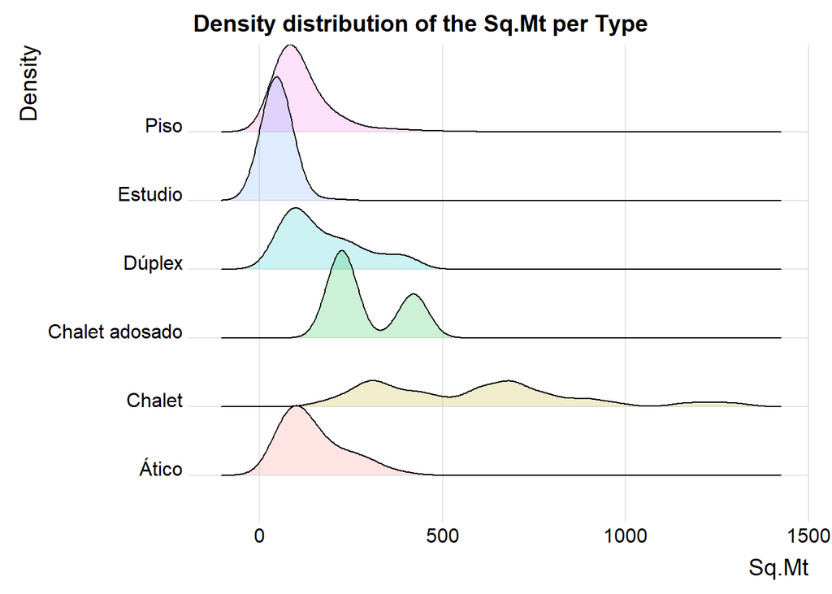

```r
# data4 %>%
#   ggplot(aes(x = Sq.Mt, color = Type)) +
#   # geom_histogram(aes(y=..density..)) +
#   geom_density(alpha=.2) +
#   labs(x = 'Log10(Sq.Mt)', y = 'Density')
#
# data4 %>%
#   ggplot(aes(x = Bedrooms, color = Type)) +
#   # geom_histogram(aes(y=..density..)) +
#   geom_density(alpha=.2) +
#   labs(x = 'Bedrooms', y = 'Density')

# http://www.sthda.com/english/articles/32-r-graphics-essentials/133-plot-one-variable-frequency-graph-density-distribution-and-more/
theme_set(theme_ridges())

data4 %>%
  ggplot(aes(x = Sq.Mt, y = Type)) +
  # geom_histogram(aes(y=..density..)) +
  geom_density_ridges(aes(fill = Type), alpha=.2) +
  labs(x = 'Sq.Mt', y = 'Density', title = 'Density distribution of the Sq.Mt per Type') +
  theme(legend.position = "none")
```

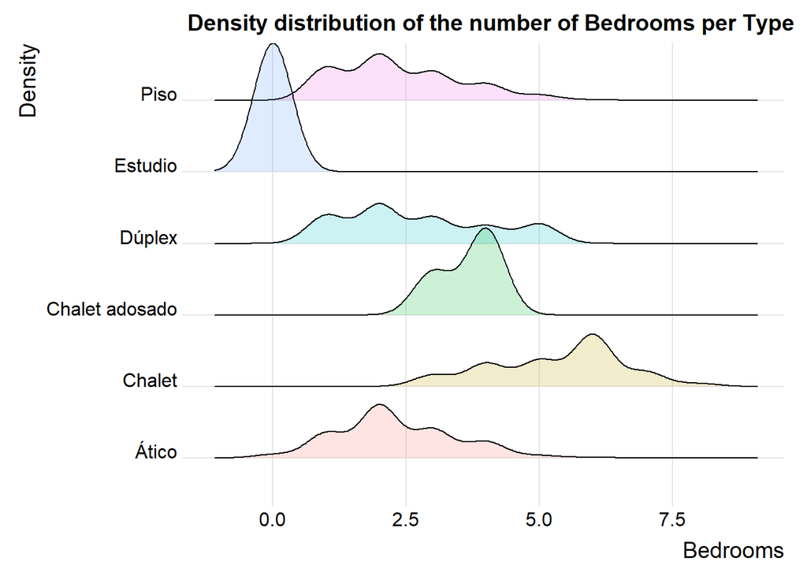

```r
data4 %>%
  ggplot(aes(x = Bedrooms, y = Type)) +
  # geom_histogram(aes(y=..density..)) +
  geom_density_ridges(aes(fill = Type), alpha=.2) +
  labs(x = 'Bedrooms', y = 'Density', title = 'Density distribution of the number of Bedrooms per Type') +
  theme(legend.position = "none")
```

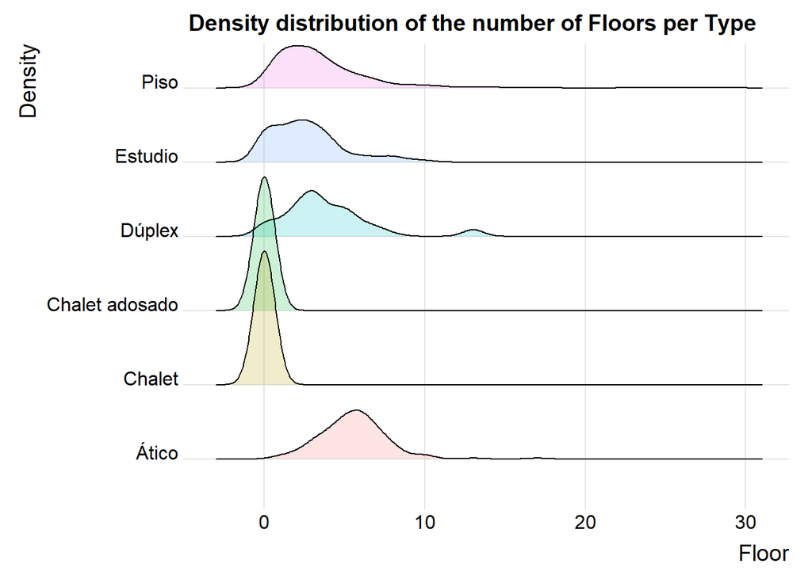

```r
data4 %>%
  ggplot(aes(x = Floor, y = Type)) +
  # geom_histogram(aes(y=..density..)) +
  geom_density_ridges(aes(fill = Type), alpha=.2) +
  labs(x = 'Floor', y = 'Density', title = 'Density distribution of the number of Floors per Type') +
  theme(legend.position = "none")
```

# Rent summary per factor

The following analysis presents the **Rent** distribution per different factors.

```r
summary_factor <- function(factor_){
  data4 %>%
    group_by_at(all_of(factor_)) %>%
    summarise(Mean=mean(Rent), SD=sd(Rent), N=n(),
              p0.25 = quantile(Rent, probs = 0.25),
              p0.50 = quantile(Rent, probs = 0.50),
              p0.75 = quantile(Rent, probs = 0.75),
              .groups = 'drop')
}

summary_outer <- summary_factor('Outer')
summary_elevator <- summary_factor('Elevator')
summary_type <- summary_factor('Type')
summary_bedrooms <- summary_factor('Bedrooms')
summary_floor <- summary_factor('Floor')

summary_sqmt <- data4 %>%
  mutate(Sq.MtRanges = cut(data4$Sq.Mt, breaks = 6)) %>%
  group_by(Sq.MtRanges) %>%
  summarise(Mean=mean(Rent), SD=sd(Rent), N=n(),
            p0.25 = quantile(Rent, probs = 0.25),
            p0.50 = quantile(Rent, probs = 0.50),
            p0.75 = quantile(Rent, probs = 0.75),
            .groups = 'drop')

knitr::kable(summary_outer)
```

| Outer | Mean | SD | N | p0.25 | p0.50 | p0.75 |
| --- | --- | --- | --- | --- | --- | --- |
| No | 2055.803 | 2154.209 | 279 | 900 | 1290 | 2130 |
| Yes | 1979.121 | 1430.321 | 1598 | 1000 | 1500 | 2500 |

```r
knitr::kable(summary_elevator)
```

| Elevator | Mean | SD | N | p0.25 | p0.50 | p0.75 |
| --- | --- | --- | --- | --- | --- | --- |
| No | 2016.773 | 2391.283 | 242 | 700 | 900 | 2190 |
| Yes | 1986.634 | 1395.125 | 1635 | 1100 | 1500 | 2500 |

```r
knitr::kable(summary_type)
```

| Type | Mean | SD | N | p0.25 | p0.50 | p0.75 |
| --- | --- | --- | --- | --- | --- | --- |
| Ático | 2513.8267 | 1590.1207 | 150 | 1400 | 2100 | 3200.00 |
| Chalet | 6094.4444 | 2758.0095 | 45 | 3750 | 5500 | 8000.00 |
| Chalet adosado | 2200.0000 | 871.7798 | 3 | 1700 | 1800 | 2500.00 |
| Dúplex | 2349.8000 | 1420.3049 | 60 | 1250 | 2125 | 3161.75 |
| Estudio | 898.7363 | 271.4514 | 91 | 700 | 850 | 1000.00 |
| Piso | 1868.7880 | 1349.7888 | 1528 | 1000 | 1400 | 2400.00 |

```r
knitr::kable(summary_bedrooms)
```

| Bedrooms | Mean | SD | N | p0.25 | p0.50 | p0.75 |
| --- | --- | --- | --- | --- | --- | --- |
| 0 | 893.000 | 267.9655 | 95 | 700 | 840 | 1000 |
| 1 | 1183.524 | 513.7483 | 429 | 850 | 1000 | 1300 |
| 2 | 1694.733 | 918.1576 | 615 | 1095 | 1400 | 2200 |
| 3 | 1991.238 | 1231.6387 | 383 | 1200 | 1600 | 2550 |
| 4 | 3109.926 | 1771.4693 | 231 | 1950 | 2600 | 3700 |
| 5 | 4199.882 | 1937.3893 | 85 | 2950 | 3700 | 5000 |
| 6 | 6679.630 | 2030.0748 | 27 | 4750 | 7500 | 8000 |
| 7 | 6242.857 | 3572.5141 | 7 | 3850 | 4500 | 8500 |
| 8 | 7860.000 | 4375.8428 | 5 | 5000 | 6000 | 9000 |

```r
knitr::kable(summary_sqmt)
```

| Sq.MtRanges | Mean | SD | N | p0.25 | p0.50 | p0.75 |
| --- | --- | --- | --- | --- | --- | --- |
| (18.7,233] | 1622.684 | 891.8752 | 1679 | 950 | 1350 | 2100 |
| (233,447] | 4401.090 | 1780.7021 | 155 | 3200 | 4000 | 5000 |
| (447,660] | 7052.083 | 1974.5929 | 24 | 5375 | 7500 | 7625 |
| (660,873] | 7816.667 | 2036.4110 | 12 | 6750 | 7500 | 8425 |
| (873,1.09e+03] | 7333.333 | 1154.7005 | 3 | 7000 | 8000 | 8000 |
| (1.09e+03,1.3e+03] | 11125.000 | 3065.2624 | 4 | 9125 | 10750 | 12750 |

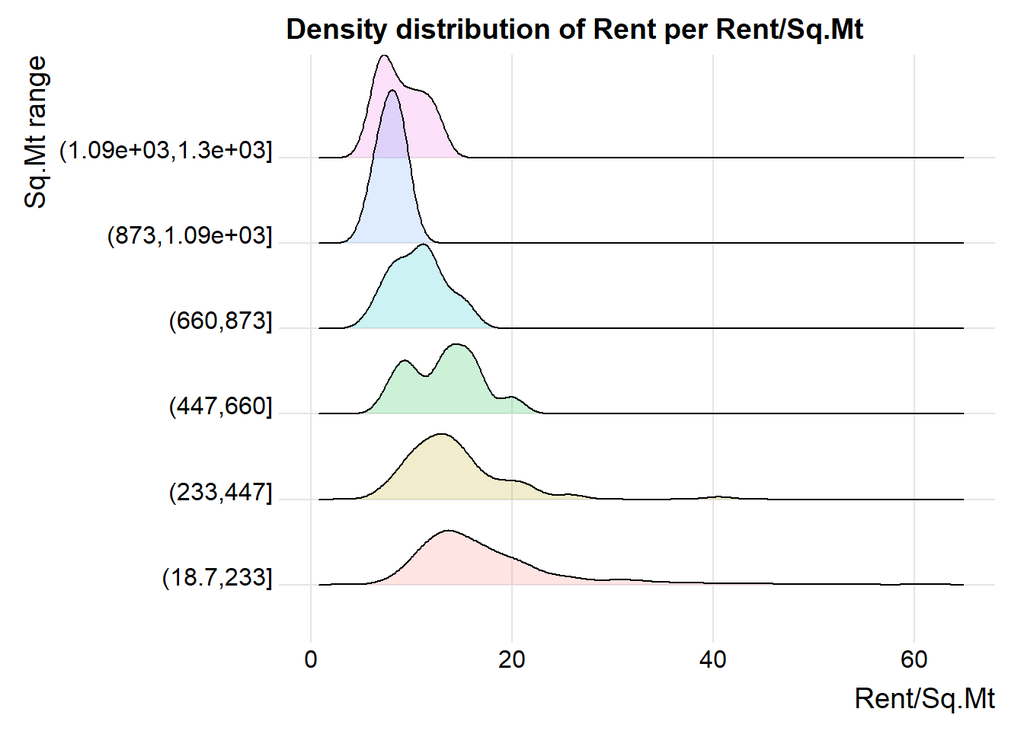

```r
data4 %>%
  mutate(Sq.MtRanges = cut(data4$Sq.Mt, breaks = 6)) %>%
  ggplot(aes(x = Rent/Sq.Mt, y = Sq.MtRanges)) +
  # geom_histogram(aes(y=..density..)) +
  geom_density_ridges(aes(fill = Sq.MtRanges), alpha=.2) +
  labs(x = 'Rent/Sq.Mt', y = 'Sq.Mt range', title = 'Density distribution of Rent per Rent/Sq.Mt') +
  theme(legend.position = "none")
```

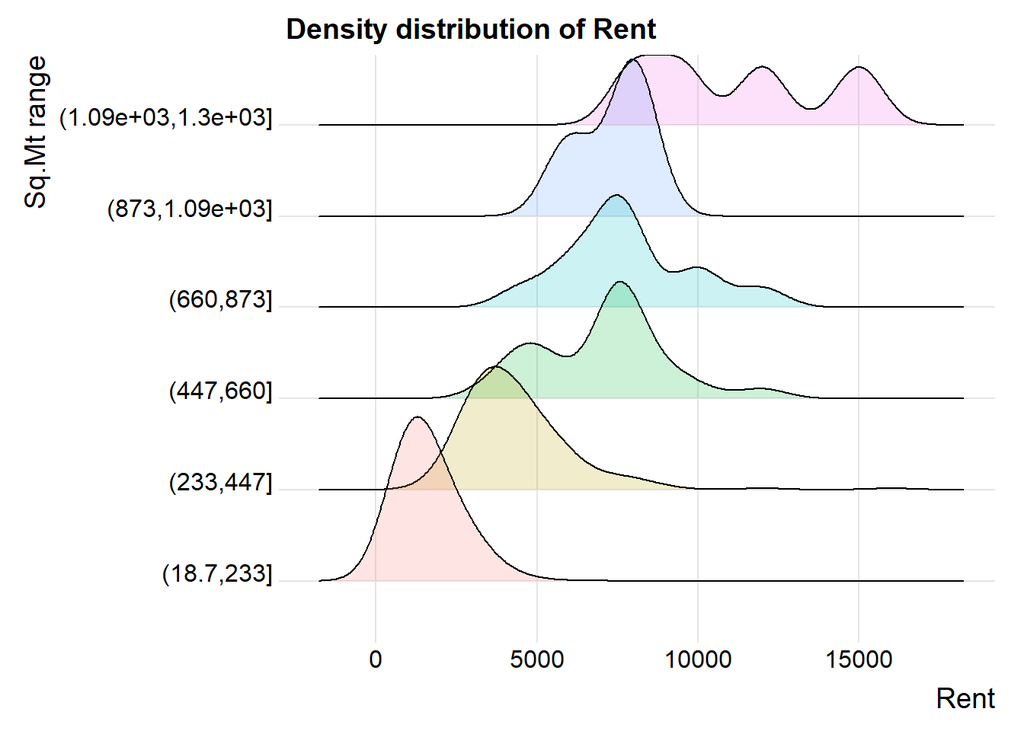

```r
data4 %>%
  mutate(Sq.MtRanges = cut(data4$Sq.Mt, breaks = 6)) %>%
  ggplot(aes(x = Rent, y = Sq.MtRanges)) +
  # geom_histogram(aes(y=..density..)) +
  geom_density_ridges(aes(fill = Sq.MtRanges), alpha=.2) +
  labs(x = 'Rent', y = 'Sq.Mt range', title = 'Density distribution of Rent') +
  theme(legend.position = "none")
```

From the plot, it can be observed as biggest the area of the property, the lowest the price of **Rent/Sq.Mt**.

# Regression

## Regression model

A linear model using *ordinary least squares* methods were used.  
To *fit* the model, there were used 1877 rows and 8 features. Three of those where categorical, so *R* convert then into factors and represents the encoded version.

```r
# Fit full model
# model_full <- glm(Rent ~ ., data = data1)
# https://stats.stackexchange.com/questions/181113/is-there-any-difference-between-lm-and-glm-for-the-gaussian-family-of-glm
# full.model1 <- lm(Rent ~ ., data = data1)
model_full <- glm(Rent ~ ., data = data5, family = gaussian(link = "identity"))
summary(model_full)
```

```
##
## Call:
## glm(formula = Rent ~ ., family = gaussian(link = "identity"),
##     data = data5)
##
## Deviance Residuals:
##     Min       1Q   Median       3Q      Max
## -5175.0   -378.8   -121.8    214.7  10747.8
##
## Coefficients:
##                      Estimate Std. Error t value Pr(>|t|)
## (Intercept)         1.610e+05  2.732e+04   5.891 4.54e-09 ***
## Bedrooms           -3.994e+00  2.288e+01  -0.175  0.86145
## Sq.Mt               1.212e+01  2.916e-01  41.573  < 2e-16 ***
## Floor               2.874e+01  6.577e+00   4.369 1.31e-05 ***
## OuterYes            5.745e+00  5.968e+01   0.096  0.92332
## ElevatorYes         2.774e+02  6.496e+01   4.270 2.05e-05 ***
## TypeChalet         -1.144e+03  1.976e+02  -5.789 8.27e-09 ***
## TypeChalet adosado -1.527e+03  4.842e+02  -3.153  0.00164 **
## TypeDúplex         -4.076e+02  1.251e+02  -3.258  0.00114 **
## TypeEstudio        -3.334e+02  1.166e+02  -2.860  0.00428 **
## TypePiso           -2.112e+02  7.170e+01  -2.946  0.00326 **
## Longitude          -6.494e+02  2.828e+02  -2.296  0.02177 *
## Latitude           -4.031e+03  6.704e+02  -6.013 2.19e-09 ***
## ---
## Signif. codes:  0 '***' 0.001 '**' 0.01 '*' 0.05 '.' 0.1 ' ' 1
##
## (Dispersion parameter for gaussian family taken to be 661387.8)
##
##     Null deviance: 4558659613  on 1876  degrees of freedom
## Residual deviance: 1232826852  on 1864  degrees of freedom
## AIC: 30497
##
## Number of Fisher Scoring iterations: 2
```

```r
# Step model
model_step <- model_full %>%
  stepAIC(trace = FALSE)
summary(model_step)
```

```
##
## Call:
## glm(formula = Rent ~ Sq.Mt + Floor + Elevator + Type + Longitude +
##     Latitude, family = gaussian(link = "identity"), data = data5)
##
## Deviance Residuals:
##     Min       1Q   Median       3Q      Max
## -5159.1   -375.8   -120.0    214.5  10750.9
##
## Coefficients:
##                      Estimate Std. Error t value Pr(>|t|)
## (Intercept)         1.610e+05  2.719e+04   5.919 3.84e-09 ***
## Sq.Mt               1.209e+01  2.089e-01  57.890  < 2e-16 ***
## Floor               2.876e+01  6.566e+00   4.379 1.26e-05 ***
## ElevatorYes         2.780e+02  6.475e+01   4.293 1.85e-05 ***
## TypeChalet         -1.147e+03  1.850e+02  -6.196 7.12e-10 ***
## TypeChalet adosado -1.532e+03  4.806e+02  -3.188  0.00145 **
## TypeDúplex         -4.085e+02  1.249e+02  -3.269  0.00110 **
## TypeEstudio        -3.288e+02  1.115e+02  -2.948  0.00323 **
## TypePiso           -2.129e+02  7.113e+01  -2.993  0.00280 **
## Longitude          -6.501e+02  2.825e+02  -2.301  0.02148 *
## Latitude           -4.032e+03  6.671e+02  -6.044 1.81e-09 ***
## ---
## Signif. codes:  0 '***' 0.001 '**' 0.01 '*' 0.05 '.' 0.1 ' ' 1
##
## (Dispersion parameter for gaussian family taken to be 660691.9)
##
##     Null deviance: 4558659613  on 1876  degrees of freedom
## Residual deviance: 1232851178  on 1866  degrees of freedom
## AIC: 30493
##
## Number of Fisher Scoring iterations: 2
```

There is small change in the model after the optimization.  
The features **Bedrooms** and **OuterYes** were removed from the final model. Let’s not forget there is a high linear correlation between the **Sq.Mt** and the **Bedrooms**.  
The *adjusted R squared* is 0.73. That adjusted $R^{2}$ value, may be interpreted as the percentage of the variability / variation of Y explained by our regression.

### Checking main statistical assumptions

Basic linear regression model is built under the following statistical assumptions.

#### Homoscedasticity in residuals

The following plot shows there is no apparent *Heteroscedasticity*. Only a few datapoints are outside the range.

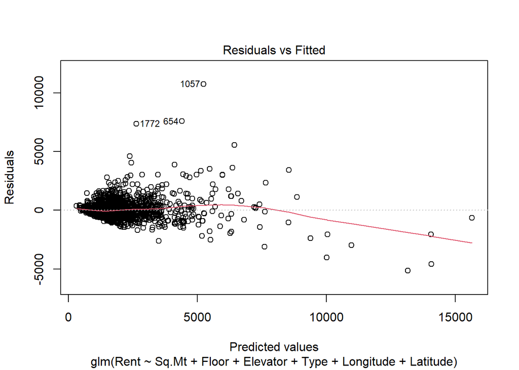

```r
plot(model_step, which=1)
```

#### Correlation

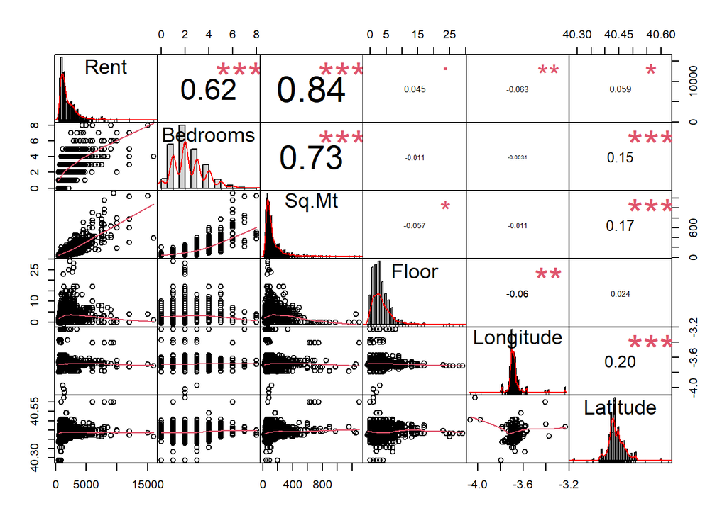

```r
data5 %>%
  # dplyr::select(Bedrooms, Sq.Mt, Floor, Longitude, Latitude) %>%
  dplyr::select_if(is.numeric) %>%
  chart.Correlation(histogram=TRUE)
```

#### Correlation between residual observations

Lack of correlation between residual observations.  
The values are *scaled* and *centered*.

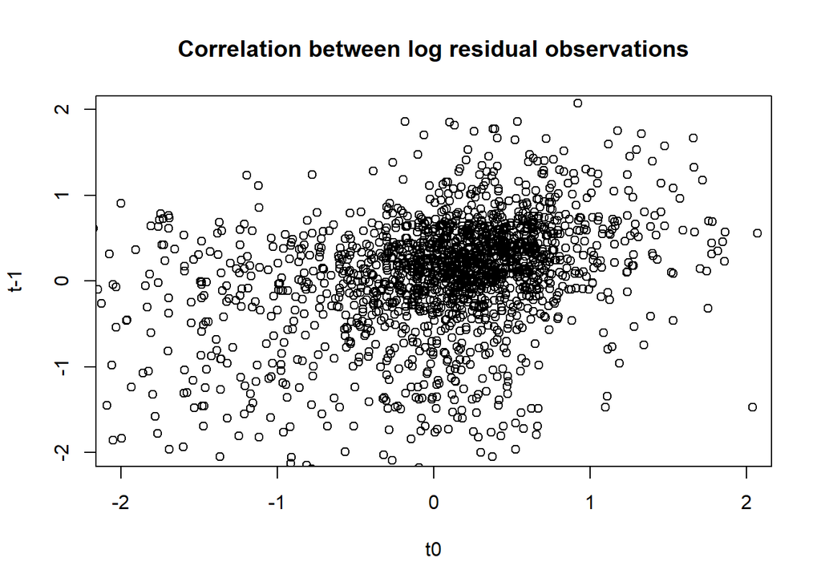

```r
temp_lag <- tibble(t0 = scale(predict(model_step, data4) - data4$Rent),
                   `t-1` = lag(t0, 1))
plot(temp_lag, main = 'Correlation between log residual observations', ylim=c(-2,2), xlim=c(-2,2))
```

#### Normality in residuals

We cannot confirm the normality in the residuals.  
The reason could be ommision of relevant variables.

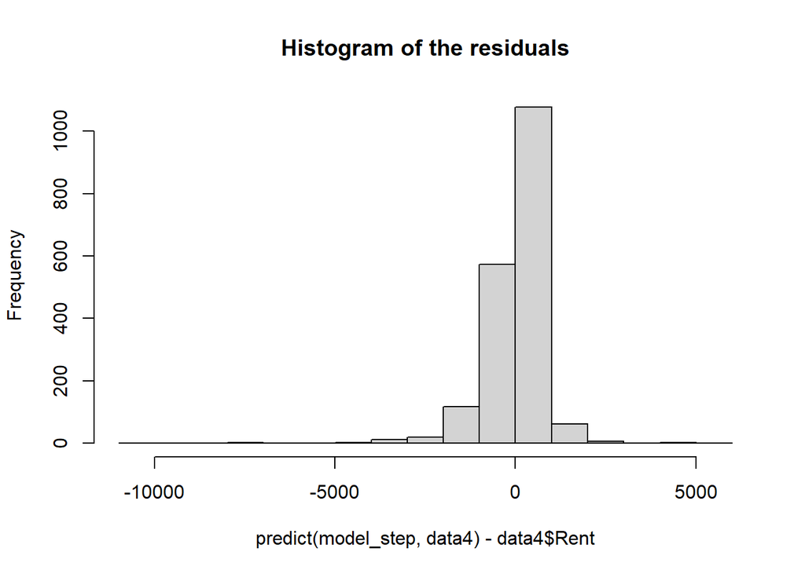

```r
hist(predict(model_step, data4) - data4$Rent, main = 'Histogram of the residuals')
```

```r
temp <- descdist(predict(model_step, data4) - data4$Rent)
```

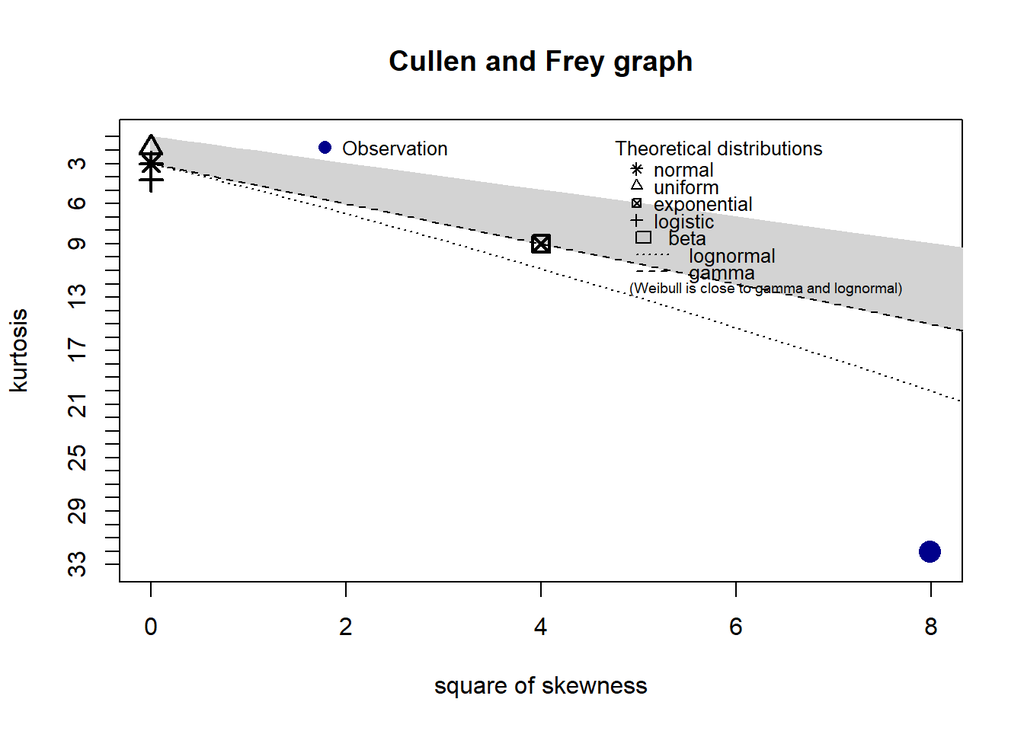

```r
shapiro.test(predict(model_step, data4) - data4$Rent)
```

```
##
##  Shapiro-Wilk normality test
##
## data:  predict(model_step, data4) - data4$Rent
## W = 0.78096, p-value < 2.2e-16
```

From the output of the **Shapiro-Wilk normality test**, the *p-value < 0.05* implying that the distribution of the data is significantly different from *normal distribution*. In other words, we cannot assume the normality.  
More variables should be included in the model to improve the capabilities.

## Impact of removing one feature at a time

The following is an excerise of remove one feature at a time and compare the *linear regression* coeficients.

```r
bind_cols(
  FeatureRemoved = c('None', colnames(data5)[2:length(colnames(data5))]),
bind_rows(
  coef(glm(Rent ~ ., data = data5, family = gaussian(link = "identity"))),
  coef(glm(Rent ~ . - Bedrooms, data = data5, family = gaussian(link = "identity"))),
  coef(glm(Rent ~ . - Sq.Mt, data = data5, family = gaussian(link = "identity"))),
  coef(glm(Rent ~ . - Floor, data = data5, family = gaussian(link = "identity"))),
  coef(glm(Rent ~ . - Outer, data = data5, family = gaussian(link = "identity"))),
  coef(glm(Rent ~ . - Elevator, data = data5, family = gaussian(link = "identity"))),
  coef(glm(Rent ~ . - Type, data = data5, family = gaussian(link = "identity"))),
  coef(glm(Rent ~ . - Longitude, data = data5, family = gaussian(link = "identity"))),
  coef(glm(Rent ~ . - Latitude, data = data5, family = gaussian(link = "identity"))))
) %>%
  knitr::kable()
```

| FeatureRemoved | (Intercept) | Bedrooms | Sq.Mt | Floor | OuterYes | ElevatorYes | TypeChalet | TypeChalet adosado | TypeDúplex | TypeEstudio | TypePiso | Longitude | Latitude |
| --- | --- | --- | --- | --- | --- | --- | --- | --- | --- | --- | --- | --- | --- |
| None | 160951.014 | -3.993939 | 12.12466 | 28.73603 | 5.744663 | 277.3533 | -1143.856 | -1526.6703 | -407.6394 | -333.44706 | -211.2243 | -649.4036 | -4031.252 |
| Bedrooms | 161142.895 | NA | 12.08961 | 28.73211 | 4.718554 | 277.6206 | -1141.163 | -1527.6626 | -408.2066 | -327.90166 | -212.6637 | -650.6441 | -4036.193 |
| Sq.Mt | 166246.673 | 650.921322 | NA | 28.65275 | 113.502783 | 591.1060 | 2603.191 | -230.2382 | -311.4919 | 82.86558 | -594.6766 | -1321.6455 | -4226.896 |
| Floor | 157979.985 | -3.651869 | 12.12427 | NA | 17.493012 | 325.4945 | -1248.409 | -1626.8330 | -456.1884 | -405.87816 | -268.0517 | -721.5199 | -3961.826 |
| Outer | 160747.179 | -3.776964 | 12.12588 | 28.76456 | NA | 277.7974 | -1150.151 | -1532.1753 | -408.0103 | -334.25579 | -211.5939 | -648.8569 | -4026.057 |
| Elevator | 143255.417 | -6.297577 | 12.26934 | 33.49913 | 23.844032 | NA | -1432.981 | -1770.3387 | -405.0827 | -339.73186 | -209.1345 | -622.9264 | -3586.259 |
| Type | 185945.491 | 13.777521 | 11.36435 | 34.98317 | 124.864872 | 403.2862 | NA | NA | NA | NA | NA | -759.1184 | -4669.394 |
| Longitude | 175621.180 | -5.314181 | 12.16295 | 29.61738 | 2.992342 | 274.0827 | -1163.738 | -1567.3160 | -411.9733 | -347.95742 | -213.7030 | NA | -4334.839 |
| Latitude | -3211.479 | -9.802390 | 12.13697 | 27.79883 | -23.140776 | 216.6393 | -1336.682 | -1642.5525 | -439.1671 | -326.52235 | -203.3403 | -984.7362 | NA |

The removal of **Sq.Mt** makes a big change in the coefficients.  
Also the coeficient of 12.1246562 stays almost inmutable by removing the other features. This number represents a change of 1 unit of **Rent** by changing 1 unit of **Sq.Mt** as long the other variables remains constant .  
That means, 1 extra square meter of property will increase the rent price by 12.1246562 EUR as long the other variables remains constant.

## Model summary table: Scaled

Scaling the variables, allows the reader to compare the different variables in the model.

```r
# Scaled
data_7_temp <- data5 %>%
  mutate_if(is.numeric, scale)
model_step_scaled <- glm(formula(model_step), data = data_7_temp, family = gaussian(link = "identity"))
summary(model_step_scaled)
```

```
##
## Call:
## glm(formula = formula(model_step), family = gaussian(link = "identity"),
##     data = data_7_temp)
##
## Deviance Residuals:
##     Min       1Q   Median       3Q      Max
## -3.3096  -0.2410  -0.0770   0.1376   6.8967
##
## Coefficients:
##                    Estimate Std. Error t value Pr(>|t|)
## (Intercept)        -0.00634    0.05732  -0.111  0.91194
## Sq.Mt               0.91328    0.01578  57.890  < 2e-16 ***
## Floor               0.05590    0.01276   4.379 1.26e-05 ***
## ElevatorYes         0.17832    0.04154   4.293 1.85e-05 ***
## TypeChalet         -0.73549    0.11871  -6.196 7.12e-10 ***
## TypeChalet adosado -0.98290    0.30828  -3.188  0.00145 **
## TypeDúplex         -0.26205    0.08015  -3.269  0.00110 **
## TypeEstudio        -0.21094    0.07154  -2.948  0.00323 **
## TypePiso           -0.13658    0.04563  -2.993  0.00280 **
## Longitude          -0.02846    0.01237  -2.301  0.02148 *
## Latitude           -0.07702    0.01274  -6.044 1.81e-09 ***
## ---
## Signif. codes:  0 '***' 0.001 '**' 0.01 '*' 0.05 '.' 0.1 ' ' 1
##
## (Dispersion parameter for gaussian family taken to be 0.2718909)
##
##     Null deviance: 1876.00  on 1876  degrees of freedom
## Residual deviance:  507.35  on 1866  degrees of freedom
## AIC: 2895.1
##
## Number of Fisher Scoring iterations: 2
```

As summary, the coefficient of the model are the following.  
This analysis, compares the measured and unitless (*scaled*) variables.

```r
# First version of the summary
summary_unit <- summary(model_step)$coefficients %>%
  data.frame() %>%
  rownames_to_column()
summary_scaled <- summary(model_step_scaled)$coefficients %>%
  data.frame() %>%
  rownames_to_column() %>%
  rename_all(function(x) paste(x, 'scaled', sep = '_'))
bind_cols(summary_unit,
          dplyr::select(summary_scaled, Estimate_scaled, Std..Error_scaled, t.value_scaled)) %>%
  magrittr::set_colnames(c('Feature', 'Estimate', 'Std. Error', 't value', 'Pr(>|t|)', 'Estimate scaled', 'Std. Error scaled', 't value scaled')) %>%
  knitr::kable()
```

| Feature | Estimate | Std. Error | t value | Pr(>\|t\|) | Estimate scaled | Std. Error scaled | t value scaled |
| --- | --- | --- | --- | --- | --- | --- | --- |
| (Intercept) | 160965.18281 | 2.719328e+04 | 5.919301 | 0.0000000 | -0.0063403 | 0.0573230 | -0.110607 |
| Sq.Mt | 12.09220 | 2.088809e-01 | 57.890391 | 0.0000000 | 0.9132764 | 0.0157760 | 57.890391 |
| Floor | 28.75594 | 6.566367e+00 | 4.379277 | 0.0000126 | 0.0558982 | 0.0127643 | 4.379277 |
| ElevatorYes | 277.97695 | 6.474978e+01 | 4.293095 | 0.0000185 | 0.1783227 | 0.0415371 | 4.293095 |
| TypeChalet | -1146.50521 | 1.850448e+02 | -6.195824 | 0.0000000 | -0.7354851 | 0.1187066 | -6.195824 |
| TypeChalet adosado | -1532.18385 | 4.805626e+02 | -3.188312 | 0.0014548 | -0.9828986 | 0.3082818 | -3.188312 |
| TypeDúplex | -408.48863 | 1.249472e+02 | -3.269290 | 0.0010978 | -0.2620462 | 0.0801538 | -3.269290 |
| TypeEstudio | -328.82232 | 1.115224e+02 | -2.948486 | 0.0032330 | -0.2109401 | 0.0715418 | -2.948486 |
| TypePiso | -212.90539 | 7.112630e+01 | -2.993343 | 0.0027956 | -0.1365792 | 0.0456276 | -2.993343 |
| Longitude | -650.13463 | 2.824994e+02 | -2.301366 | 0.0214807 | -0.0284605 | 0.0123668 | -2.301366 |
| Latitude | -4031.66116 | 6.670607e+02 | -6.043920 | 0.0000000 | -0.0770158 | 0.0127427 | -6.043920 |

```r
# Second version of the summary
regression_table <- function(x, x_scaled, level = 0.95) {
  table <- cbind(
    summary(x)$coefficients,
    summary(x_scaled)$coefficients[, 'Estimate'],
    confint.default(x, level = level))
  colnames(table)[5] <- "Estimate Std."
  return(table)
}

#regression_table(model_step, model_step_scaled) %>%
#  knitr::kable()
```

The *scaling*, allows to check the importance of a variable, for example the **TypeChalet adosado** is the one that produces the highest variation of the **Rent**, and also the relation is *negative*. See column *Estimate scaled* (as long the other variables remains constant).  
The second one, is the **Sq.Mt**, afecting in a positive way.

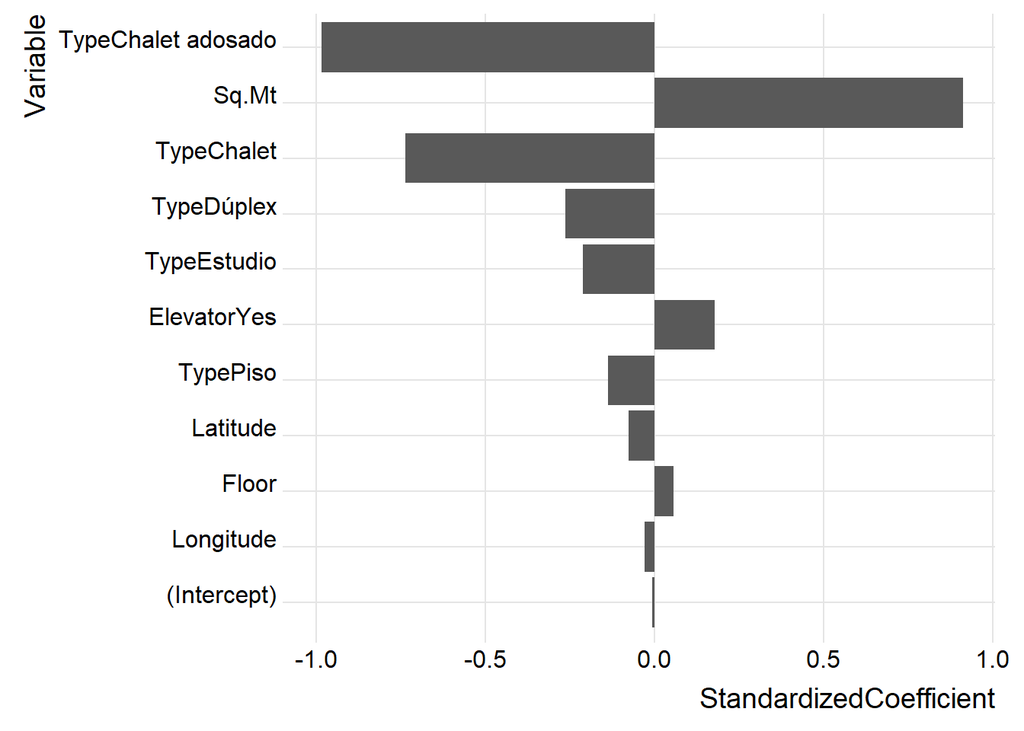

```r
data_8_temp <- summary(model_step_scaled)$coefficients[, 'Estimate']
data_8_temp <- data.frame(Variable = names(data_8_temp), StandardizedCoefficient = as.numeric(data_8_temp))
data_8_temp <- arrange(data_8_temp, abs(StandardizedCoefficient))
data_8_temp$Variable <- factor(data_8_temp$Variable, levels = data_8_temp$Variable)

ggplot(data=data_8_temp, aes(x=Variable, y=StandardizedCoefficient)) +
  geom_bar(stat="identity") +
  coord_flip()
```

The previous plot, shows the importance per variable in the same unit. Where **Type Chalet adosado** has the biggest impact in the **Rent**, as long the other variables remains constant.  
The sign tells if the variable affects the **Rent** in a possitive or negative way. That is, one unit of the variable increase or decrease the **Rent**.

# Good opportunities

Following, there is a list of the top 15 properties with *Real* price bellow their theoretical *Predicted* price.  
The **Ratio** captures how many times better the *Real* price is compared to the *Predicted*.  
The **Rent** is in *EUR/month*.

```r
# Find good opportunities in the market looking for flats that may be under their theoretical estimated price

data_6_temp <- data4
data_6_temp$Prediction <- predict(model_step, data_6_temp)
data_6_temp$Ratio <- data_6_temp$Prediction/data_6_temp$Rent-1

data_6_temp %>%
  filter(Ratio>0) %>%
  top_n(Ratio, n = 15) %>%
  dplyr::select(Id, Type, AddressComplete, Rent, Ratio) %>%
  mutate(Ratio = round(Ratio, 2)) %>%
  arrange(desc(Ratio)) %>%
  knitr::kable()
```

| Id | Type | AddressComplete | Rent | Ratio |
| --- | --- | --- | --- | --- |
| 2188 | Estudio | Avenida Real De Pinto, 5, San Andrés, Madrid, Spain | 900 | 2.89 |
| 2171 | Piso | Carretera De Carabanchel A Villaverde, 1, San Andrés, Madrid, Spain | 650 | 2.14 |
| 2176 | Piso | Calle De Tordegrillos, 1, San Andrés, Madrid, Spain | 640 | 2.10 |
| 2181 | Piso | Calle Terriente, 1, San Andrés, Madrid, Spain | 450 | 2.06 |
| 2169 | Piso | Calle Los Bohemios, 1, Los Ángeles, Madrid, Spain | 700 | 2.03 |
| 2187 | Piso | Calle Del Doctor Martãn Arã©Valo, 35, San Andrés, Madrid, Spain | 750 | 1.93 |
| 2173 | Piso | Calle De Palomares, 58, San Andrés, Madrid, Spain | 600 | 1.79 |
| 375 | Ático | Calle Santa Cecilia, 8, Lucero, Madrid, Spain | 1000 | 1.68 |
| 2183 | Piso | Avenida De La Verbena De La Paloma, 37, Los Ángeles, Madrid, Spain | 650 | 1.57 |
| 1438 | Piso | Calle De Matilde Hernandez, 1, Vista Alegre, Madrid, Spain | 590 | 1.53 |
| 596 | Piso | Arroyo Del Olivar, 1, Portazgo, Madrid, Spain | 650 | 1.44 |
| 366 | Piso | Calle Maqueda, 1, Aluche, Madrid, Spain | 900 | 1.42 |
| 2174 | Piso | Calle Lillo, 1, Los Ángeles, Madrid, Spain | 950 | 1.42 |
| 363 | Piso | Los Yebenes, 1, Aluche, Madrid, Spain | 800 | 1.41 |
| 369 | Piso | Calle De Maqueda, 136, Aluche, Madrid, Spain | 850 | 1.41 |

## Map

Following, are presented the most relevant renting opportunities per **Type**.

```r
# Labels for the map ----
data_6_temp$Label <-
  paste('<strong>', data_6_temp$Type, '</strong>', '<br/>',
        'Location:', data_6_temp$AddressComplete, '<br/>',
        'Rent price:', round(data_6_temp$Rent, 1), 'EUR/month', '<br/>',
        'Theoretical rent price:', round(data_6_temp$Prediction, 1), 'EUR/month', '<br/>',
        'Id:', data_6_temp$Id
        ) %>%
  lapply(HTML)
```

### Piso

Interesting opportunities for **Piso** or *Flat*.  
Only showing the ones we were able to geolocate (assign latitude and longitude), and also the ration between estimated rent price and real, is greater than 1x.

```r
data_7_temp <- data_6_temp %>%
  filter(Ratio>1, Type == 'Piso')

# make palette
# https://cran.r-project.org/web/packages/viridis/vignettes/intro-to-viridis.html
pallete_ <- colorNumeric(palette = magma(20), domain = range(data_7_temp$Ratio))

data_7_temp %>%
  leaflet() %>%
    addProviderTiles(providers$CartoDB.Positron) %>%
    addCircleMarkers(~Longitude, ~Latitude,
                     popup = ~Label,
                     label = ~Type,
                     color = ~pallete_(Ratio))
```

[interactive chart not shown]

### Ático

Interesting opportunities for **Ático**.  
Additionally, we are adding *Penthouse* opportunities.

```r
data_7_temp <- data_6_temp %>%
  filter(Ratio>1, Type == 'Ático')

# make palette
# https://cran.r-project.org/web/packages/viridis/vignettes/intro-to-viridis.html
pallete_ <- colorNumeric(palette = magma(20), domain = range(data_7_temp$Ratio))

data_7_temp %>%
  leaflet() %>%
    addProviderTiles(providers$CartoDB.Positron) %>%
    addCircleMarkers(~Longitude, ~Latitude,
                     popup = ~Label,
                     label = ~Type,
                     color = ~pallete_(Ratio))
```

[interactive chart not shown]

### Estudio

Interesting opportunities for **Estudio**.  
These properties, are single-storey.

```r
data_7_temp <- data_6_temp %>%
  filter(Ratio>1, Type == 'Estudio')

# make palette
# https://cran.r-project.org/web/packages/viridis/vignettes/intro-to-viridis.html
pallete_ <- colorNumeric(palette = magma(20), domain = range(data_7_temp$Ratio))

data_7_temp %>%
  leaflet() %>%
    addProviderTiles(providers$CartoDB.Positron) %>%
    addCircleMarkers(~Longitude, ~Latitude,
                     popup = ~Label,
                     label = ~Type,
                     color = ~pallete_(Ratio))
```

[interactive chart not shown]